# Trabajo Práctico 2

Septiembre 2025

#### Universidad: UNO - Especialización en Ciencia de Datos

#### Materia: Modelos para el Aprendizaje Automático (01052)

##### Profesor: Mg. Silvia Perez

##### Alumnos: Grupo 3 (Lic. Leticia Sosa, Ing. Federico Czerniawski, Mg. Ing. Pablo Pandolfo)

### 1. Exploración y análisis de datos

Durante la exploración de los datos incluidos en el archivo “cancelacion.csv” se detectó lo siguiente:

- Se observa un único dato faltante en la variable **hs_sin_conexion**, y por ser sólo uno se decide eliminar.
- Las variables **packtv** y **cancela** son categóricas, por lo que se las convierte en factor.
- Se observa que las variables **carga_extra** y **min_llam** presentan alta correlación. Esto tiene sentido ya que mientras más minutos consuma el usuario más necesidad tendrá de contratar carga extra. Esta situación será tenida en cuenta más adelante.

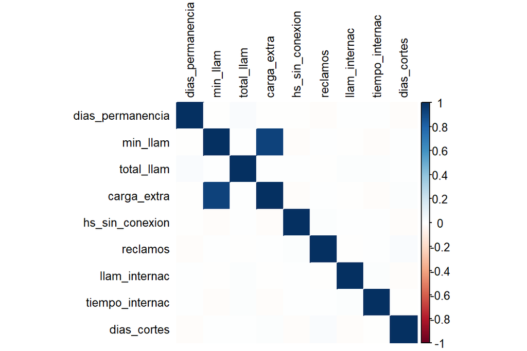

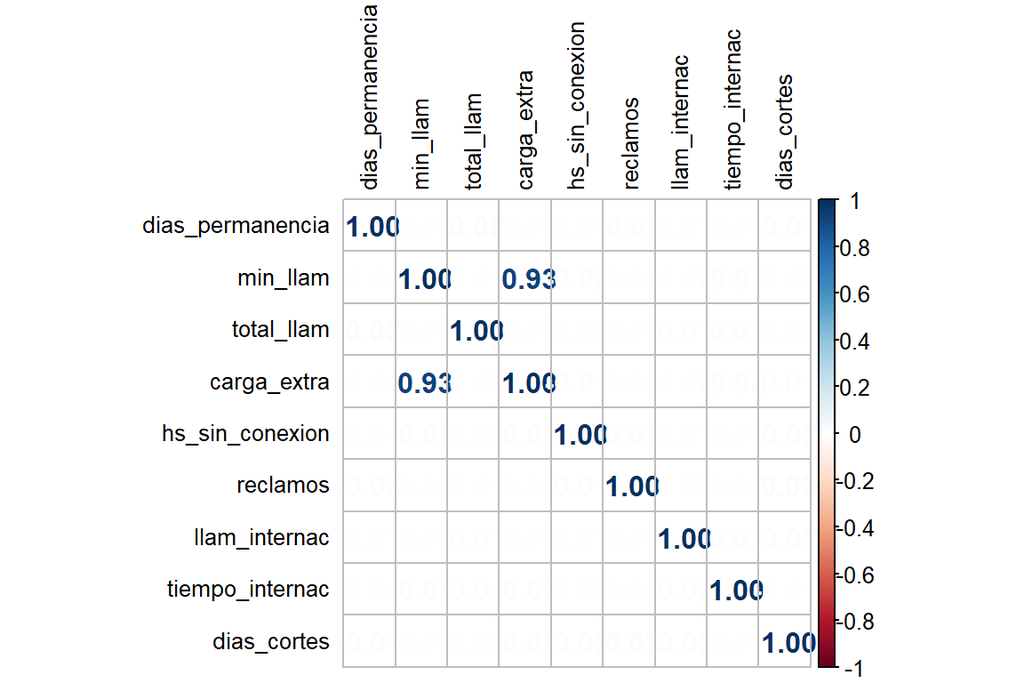

- Se observa que las variables **hs_sin_conexion** y **llam_internac** presentan datos erróneos, son negativos, inconsistente con la definición de la variable. Se los procede a eliminar.
- Se observa que las variables **dias_permanencia** y **min_llam** presentan datos atípicos, muy alejados del resto del set de datos. Se los procede a eliminar.

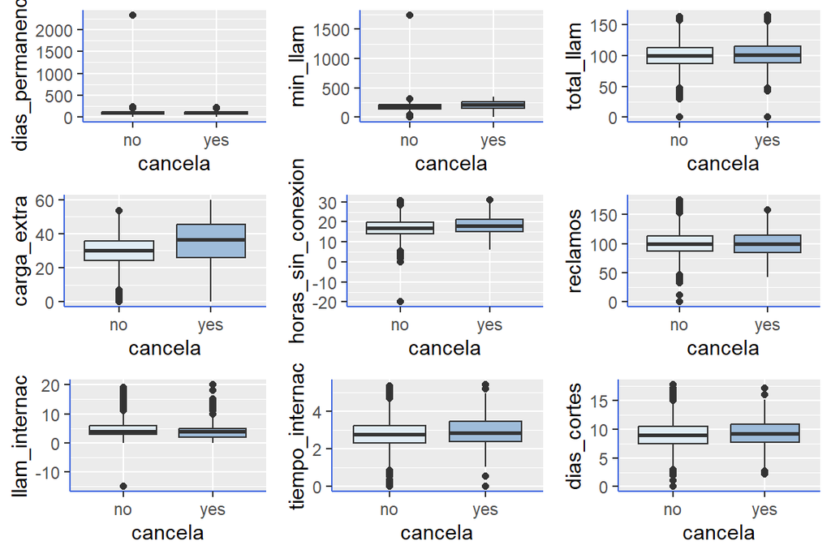

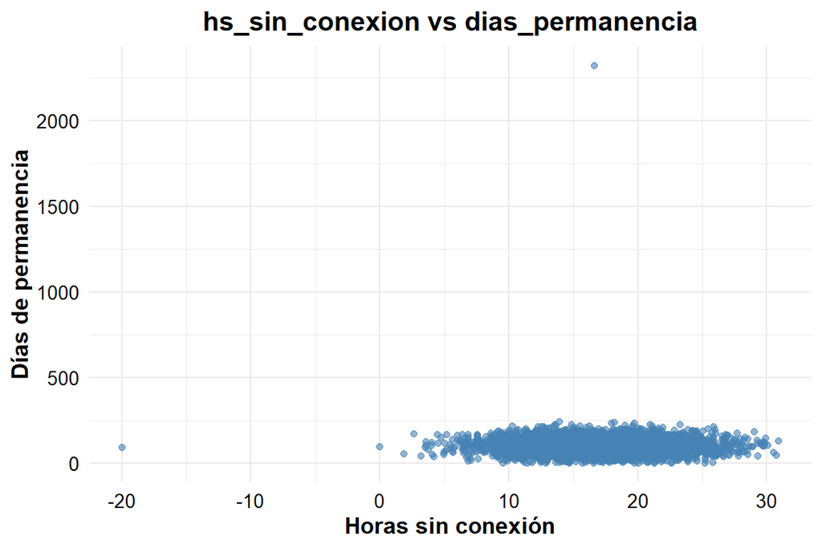

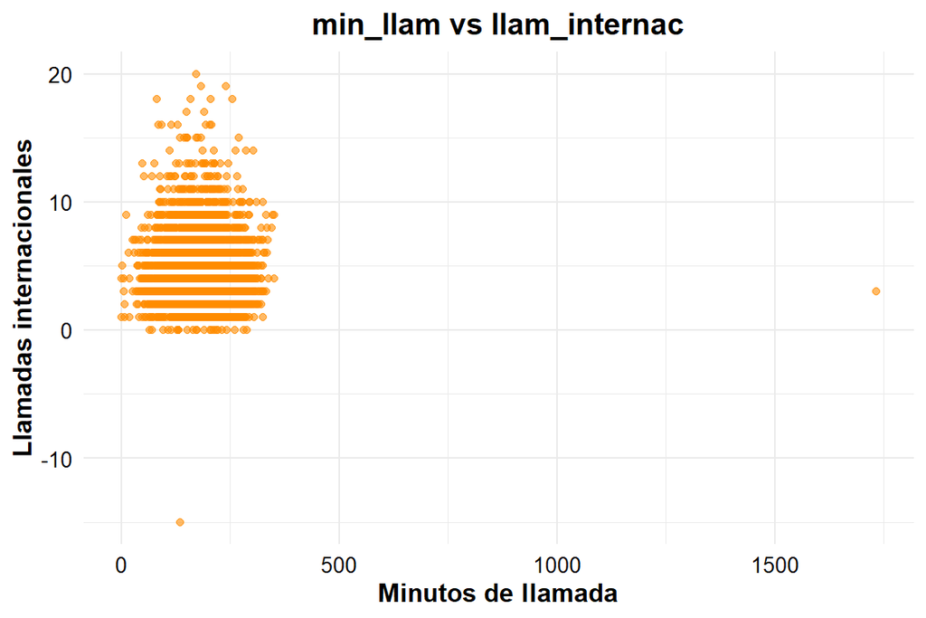

### 2. Ajuste de Modelos

Se separó el conjunto de datos original, que contaba con 4995 observaciones, en dos conjuntos de datos: un conjunto **train** (entrenamiento) con **3497** observaciones y otro conjunto **test** (validación) con **1498**.

La separación se realizó en forma aleatoria con la proporción **70/30.**

#### Modelo de regresión logística

1. Se ajustó un mod_full con todas las variables.

```
##
## Call:
## glm(formula = cancela ~ ., family = "binomial", data = train)
##
## Coefficients:
##                    Estimate Std. Error z value Pr(>|z|)
## (Intercept)      -6.375e+00  5.725e-01 -11.136  < 2e-16 ***
## dias_permanencia  2.170e-03  1.285e-03   1.689  0.09118 .
## packtvyes        -9.478e-01  1.384e-01  -6.850 7.41e-12 ***
## min_llam          4.659e+00  3.017e+00   1.544  0.12251
## total_llam        2.789e-04  2.534e-03   0.110  0.91238
## carga_extra      -2.734e+01  1.775e+01  -1.540  0.12346
## hs_sin_conexion   7.713e-02  1.201e-02   6.420 1.36e-10 ***
## reclamos         -1.403e-03  2.551e-03  -0.550  0.58233
## llam_internac    -6.956e-02  2.213e-02  -3.143  0.00167 **
## tiempo_internac   3.093e-01  6.873e-02   4.500 6.81e-06 ***
## dias_cortes       5.677e-02  2.194e-02   2.587  0.00967 **
## ---
## Signif. codes:  0 '***' 0.001 '**' 0.01 '*' 0.05 '.' 0.1 ' ' 1
##
## (Dispersion parameter for binomial family taken to be 1)
##
##     Null deviance: 2851.9  on 3496  degrees of freedom
## Residual deviance: 2576.2  on 3486  degrees of freedom
## AIC: 2598.2
##
## Number of Fisher Scoring iterations: 5
```

2. Se ajustó un modelo **modelo1** con todas las variables y con el método Stepwise Backward (Selección hacia Atrás) se seleccionó el mejor modelo que contiene las siguientes variables significativas:
- # - packtv
- # - hs_sin_conexion
- # - llam_internac
- # - tiempo_internac
- # - dias_cortes

modelo1: cancela ~ dias_permanencia + packtv + min_llam + carga_extra + hs_sin_conexion + llam_internac + tiempo_internac + dias_cortes

Comparando contra el **mod_full**, son modelos muy similares en cuanto a la significancia de variables, devianza y el valor de AIC.

Optamos por el **modelo1** por ser más simple

```
##
## Call:
## glm(formula = cancela ~ dias_permanencia + packtv + min_llam +
##     carga_extra + hs_sin_conexion + llam_internac + tiempo_internac +
##     dias_cortes, family = "binomial", data = train)
##
## Coefficients:
##                    Estimate Std. Error z value Pr(>|z|)
## (Intercept)       -6.484939   0.453991 -14.284  < 2e-16 ***
## dias_permanencia   0.002182   0.001284   1.700  0.08919 .
## packtvyes         -0.947711   0.138371  -6.849 7.43e-12 ***
## min_llam           4.688378   3.016541   1.554  0.12013
## carga_extra      -27.509685  17.744343  -1.550  0.12106
## hs_sin_conexion    0.077043   0.012013   6.413 1.42e-10 ***
## llam_internac     -0.069383   0.022123  -3.136  0.00171 **
## tiempo_internac    0.308696   0.068682   4.495 6.97e-06 ***
## dias_cortes        0.056661   0.021945   2.582  0.00982 **
## ---
## Signif. codes:  0 '***' 0.001 '**' 0.01 '*' 0.05 '.' 0.1 ' ' 1
##
## (Dispersion parameter for binomial family taken to be 1)
##
##     Null deviance: 2851.9  on 3496  degrees of freedom
## Residual deviance: 2576.5  on 3488  degrees of freedom
## AIC: 2594.5
##
## Number of Fisher Scoring iterations: 5
```

3. Considerando sólo las variables numéricas se propone el **modelo2**:
- cancela ~ dias_permanencia + min_llam + carga_extra + hs_sin_conexion + llam_internac + tiempo_internac + dias_cortes

El modelo1 parece ser superior al modelo2. Claramente el haber eliminado la variable categórica packtv (que es altamente significativa en el modelo1) no fue una buena decisión.

```
##
## Call:
## glm(formula = cancela ~ dias_permanencia + min_llam + carga_extra +
##     hs_sin_conexion + llam_internac + tiempo_internac + dias_cortes,
##     family = "binomial", data = train)
##
## Coefficients:
##                    Estimate Std. Error z value Pr(>|z|)
## (Intercept)       -6.513933   0.447977 -14.541  < 2e-16 ***
## dias_permanencia   0.002176   0.001275   1.707  0.08791 .
## min_llam           4.836184   2.991094   1.617  0.10591
## carga_extra      -28.380175  17.594617  -1.613  0.10674
## hs_sin_conexion    0.073429   0.011908   6.166 7.00e-10 ***
## llam_internac     -0.066419   0.021891  -3.034  0.00241 **
## tiempo_internac    0.294722   0.068054   4.331 1.49e-05 ***
## dias_cortes        0.051859   0.021660   2.394  0.01665 *
## ---
## Signif. codes:  0 '***' 0.001 '**' 0.01 '*' 0.05 '.' 0.1 ' ' 1
##
## (Dispersion parameter for binomial family taken to be 1)
##
##     Null deviance: 2851.9  on 3496  degrees of freedom
## Residual deviance: 2631.3  on 3489  degrees of freedom
## AIC: 2647.3
##
## Number of Fisher Scoring iterations: 5
```

4. **Modelo3**: se ajustó un modelo con las variables significativas del **Modelo1**.

Sin embargo, los valores de AIC y Devianza residual no son mejores que los del modelo1.

```
##
## Call:
## glm(formula = cancela ~ packtv + hs_sin_conexion + llam_internac +
##     tiempo_internac + dias_cortes, family = "binomial", data = train)
##
## Coefficients:
##                 Estimate Std. Error z value Pr(>|z|)
## (Intercept)     -3.90462    0.36852 -10.596  < 2e-16 ***
## packtvyes       -0.90712    0.13565  -6.687 2.27e-11 ***
## hs_sin_conexion  0.07276    0.01171   6.211 5.25e-10 ***
## llam_internac   -0.06339    0.02149  -2.950  0.00318 **
## tiempo_internac  0.26942    0.06711   4.015 5.96e-05 ***
## dias_cortes      0.05847    0.02159   2.708  0.00676 **
## ---
## Signif. codes:  0 '***' 0.001 '**' 0.01 '*' 0.05 '.' 0.1 ' ' 1
##
## (Dispersion parameter for binomial family taken to be 1)
##
##     Null deviance: 2851.9  on 3496  degrees of freedom
## Residual deviance: 2732.7  on 3491  degrees of freedom
## AIC: 2744.7
##
## Number of Fisher Scoring iterations: 5
```

### Test de bondad de ajuste

#### Análisis de los 4 modelos con AIC:

|  | df | AIC |
| --- | --- | --- |
| mod_full | 11 | 2598.156 |
| modelo1 | 9 | 2594.472 |
| modelo2 | 8 | 2647.311 |
| modelo3 | 6 | 2744.685 |

#### Análisis de devianzas con ANOVA

|  | Resid. Df | Resid. Dev | Df | Deviance | Pr(>Chi) |
| --- | --- | --- | --- | --- | --- |
| 1 | 3486 | 2576.156 | NA | NA | NA |
| 2 | 3488 | 2576.472 | -2 | -0.3154573 | 8.540815e-01 |
| 3 | 3489 | 2631.311 | -1 | -54.8392108 | 1.308049e-13 |
| 4 | 3491 | 2732.685 | -2 | -101.3738503 | 9.703940e-23 |

Al realizar la comparación de devianzas utilizando ANOVA en los 4 modelos se observa:

- Orden de la comparación: mod_full, modelo1, modelo2, modelo3
- Linea N°2 - mod_full vs modelo1: La devianza residual del modelo1 es levemente mayor pero esa diferencia NO es estadísticamente significativa (p-valor muy alto). El modelo1 es preferible por su parsimonia.
- Linea N°3 - modelo1 vs modelo2: La devianza residual del modelo2 es bastante mayor y esa diferencia es altamente signicativa (p-valor menor a 0.05). Se mantiene modelo1 como el mejor.
- Linea N°4 - modelo2 vs modelo3: La devianza residual del modelo3 es bastante mayor y esa diferencia es altamente signicativa (p-valor menor a 0.05). Entre ambos, es mejor el modelo2.

El modelo1 es el más recomendable en base a la bondad de ajuste, además es más simple que el mod_full (que excluye algunas variables no significativas)

#### Análisis de Pseudo R2

Comparación de Métricas Pseudo R2

|  | mod_full | modelo1 | modelo2 | modelo3 |
| --- | --- | --- | --- | --- |
| CoxSnell | 0.07583 | 0.07575 | 0.06114 | 0.03352 |
| Nagelkerke | 0.13599 | 0.13584 | 0.10964 | 0.06012 |

#### Test de Hosmer-Lemeshow

```
## [1] "mod_full"
```

```
##
##  Hosmer and Lemeshow goodness of fit (GOF) test
##
## data:  mod_full$y, fitted(mod_full)
## X-squared = 261.11, df = 8, p-value < 2.2e-16
```

```
## [1] "modelo1"
```

```
##
##  Hosmer and Lemeshow goodness of fit (GOF) test
##
## data:  modelo1$y, fitted(modelo1)
## X-squared = 264.89, df = 8, p-value < 2.2e-16
```

```
## [1] "modelo2"
```

```
##
##  Hosmer and Lemeshow goodness of fit (GOF) test
##
## data:  modelo2$y, fitted(modelo2)
## X-squared = 214.83, df = 8, p-value < 2.2e-16
```

```
## [1] "modelo3"
```

```
##
##  Hosmer and Lemeshow goodness of fit (GOF) test
##
## data:  modelo3$y, fitted(modelo3)
## X-squared = 15.332, df = 8, p-value = 0.053
```

Las hipótesis del Test de Hosmer-Lemeshow son:

- H0: El modelo ajusta los datos.
- H1: El modelo no ajusta los datos.

Este test indica qué tan confiable es el modelo para predecir la probabilidad real de que un cliente cancele.

Para el mod_full, modelo1 y modelo2 se obtuvo un p-valor muy pequeño, se rechaza H0. El modelo no se ajusta bien a los datos.

El **modelo3** da un mejor valor de ajuste con respecto a los otros modelos (levemente superior a 0.05) pero, basandonos en los resultados de los tests anteriores, tomamos la decisión de mantener el modelo1.

**Cabe aclarar que el ajuste de modelos y los test de bondad de ajuste se realizaron con el conjunto de datos que incluía los outliers y luego se repitieron sin los outliers. En ambos casos los resultados fueron muy similares, por lo que se optó continuar con el conjunto de datos sin los outliers.

#### Análisis del modelo elegido

De acuerdo al análisis anterior, se ha elegido el **modelo1**.

**Fórmula**: cancela ~ dias_permanencia + packtv + min_llam + carga_extra + hs_sin_conexion + llam_internac + tiempo_internac + dias_cortes

Según el test de Wald, las **variables más significativas** son:

- packtv (categórica)
- hs_sin_conexion
- llam_internac
- tiempo_internac
- dias_cortes

**Test de bondad de ajuste**

Se hizo el test de bondad de ajuste con ANOVA, comparando los 4 modelos en evaluación.

Se llegó a la conclusión de que el modelo1 es el modelo estadístico que mejor se ajusta al conjunto de entrenamiento.

Si bien, no es el modelo con menor devianza residual (variabilidad que no haya sido explicada por el modelo), es el más equilibrado y más parsimonioso.

Además la diferencia de devianza con el mod_full no es estadísticamente significativa.

Cabe destacar que el test de Hosmer-Lemeshow indica que el modelo mejor calibrado para predecir la probabilidad de que un cliente cancele es el modelo3, sin embargo, por el resultado de los otros tests, se decide mantener el modelo1.

**Interpretación de coeficientes en términos de los ODDS:**

- **packtv**: Indica que tener el pack de tv contratado (packtv = yes) reduce la probabilidad de cancelar. Odds ratio = exp(-0.94) = 0.39
- **hs_sin_conexion**: Indica que por cada hora sin conexión aumenta la probabilidad de cancelar. Odds ratio = exp(0.07) = 1.08
- **llam_internac**: Indica que por cada llamada internacional realizada disminuye la probabilidad de cancelar. Odds ratio = exp(-0.06) = 0.93
- **tiempo_internac**: Indica que si hay más tiempo de llamada internacional aumenta la probabilidad de cancelar. Odds ratio = exp(0.30) = 1.36
- **dias_cortes**: Indica que más días de cortes aumenta la probabilidad de cancelar. Odds ratio = exp(0.05) = 1.06

A modo de observación:

- Los clientes que tienen el pack tv contratado, realizan mas cantidad de llamadas internacionales y poco tiempo de llamadas internacionales, tienen menos chances de cancelar.
- Los clientes que tienen más horas sin conexión, más tiempo en llamadas internacionales y más días de corte, son los que tienen más chances de cancelar.

#### Análisis de multicolinealidad (VIF)

Se observa una alta multicolinealidad en las variables **min_llam** y **carga_extra**, en parte era esperado por el análisis de correlación que realizamos al principio.

```
## dias_permanencia           packtv         min_llam      carga_extra  hs_sin_conexion
##     1.001381e+00     1.006712e+00     9.229671e+06     9.229667e+06     1.007690e+00
##    llam_internac  tiempo_internac      dias_cortes
##     1.002930e+00     1.005560e+00     1.003045e+00
```

Por ello se procedió a ajustar dos nuevos modelos separando esas variables para comparar el comportamiento: **modelo1_sin_min_llam y modelo1_sin_carga_extra.**

Analizando con AIC y ANOVA **modelo1** con **modelo1_sin_min_llam** se vizualiza que la devianza aumenta en 2.41 unidades y el p-valor no es estadisticamente significativo.

Esto indica que eliminar esa variable no empeora significativamente el ajuste, por lo que esa variable puede ser prescindible.

Entre los modelos: **modelo1_sin_min_llam** y **modelo1_sin_carga_extra** no hay diferencia en la devianza, por lo que sería lo mismo elegir cualquiera de esos modelos.

|  | df | AIC |
| --- | --- | --- |
| modelo1 | 9 | 2594.472 |
| modelo1_sin_min_llam | 8 | 2594.889 |
| modelo1_sin_carga_extra | 8 | 2594.877 |

Comparamos los modelos con anova (modelo1, modelo1_sin_min_llam, modelo1_sin_carga_extra):

|  | Resid. Df | Resid. Dev | Df | Deviance | Pr(>Chi) |
| --- | --- | --- | --- | --- | --- |
| 1 | 3488 | 2576.472 | NA | NA | NA |
| 2 | 3489 | 2578.889 | -1 | -2.41766420 | 0.1199737 |
| 3 | 3489 | 2578.877 | 0 | 0.01209257 | NA |

Finalmente, elegimos el **modelo1_sin_carga_extra** salvando la multicolinalidad. Además, el nuevo modelo resulta ser más parsimonioso que el modelo1 original.

```
## dias_permanencia           packtv         min_llam  hs_sin_conexion    llam_internac
##         1.001351         1.006711         1.009761         1.007551         1.002932
##  tiempo_internac      dias_cortes
##         1.005405         1.003021
```

#### Datos influyentes

Para detectar posibles puntos influyentes, además de los eliminados al principio, se calcula la distancia de Cook y los hatvalues.

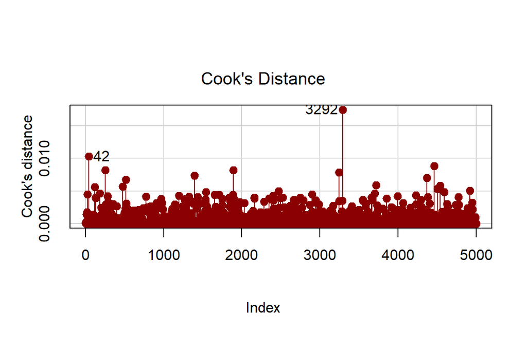

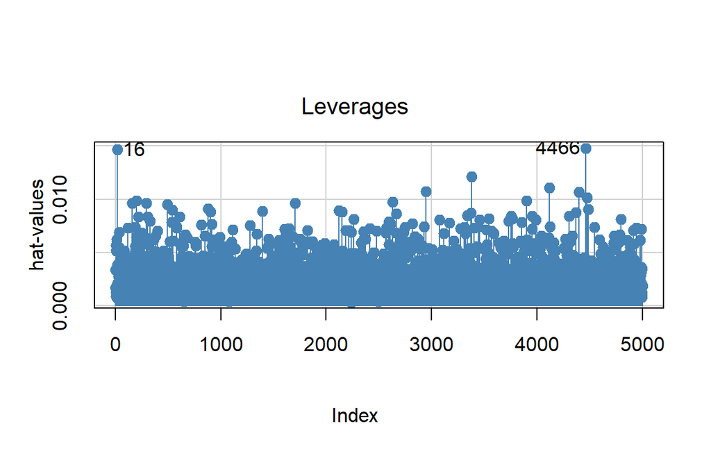

Si bien hay algunos puntos que sobresalen del resto del set de datos, no se consideran muy alejados por lo que se decide dejarlos.

#### Análisis de independencia

Otra condición necesaria para un modelo de regresión logística es que las observaciones sean **independientes**.

Por lo tanto se procedió a evaluar la independencia a traves de los Residuos de Devianza:

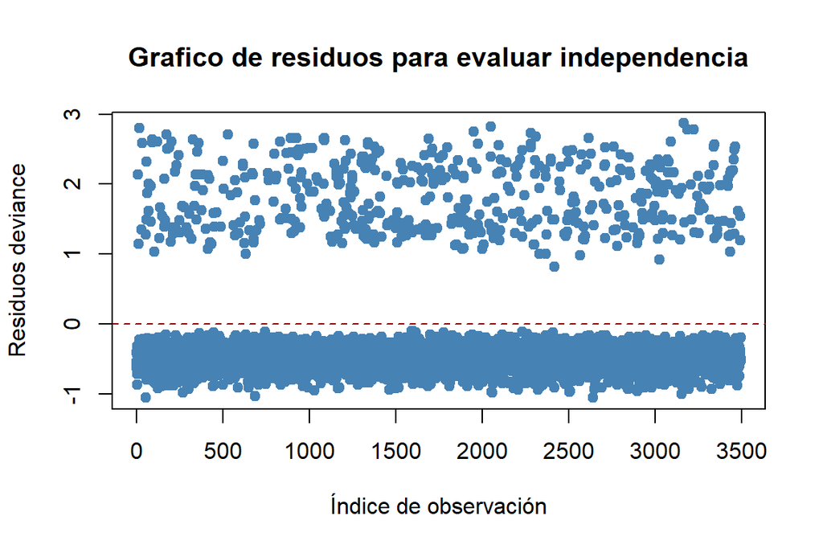

Se puede observar que ambos grupos de datos están distribuidos aleatoriamente tanto arriba como debajo de la linea horizontal Y = 0.

**Esto nos indica que las observaciones son independientes.**

### 3. Métodos de clasificación

Se ajustaron modelos de clasificación con los métodos Naive Bayes, KNN y SVM.

#### Naive Bayes

```
##
## Naive Bayes Classifier for Discrete Predictors
##
## Call:
## naiveBayes.default(x = X, y = Y, laplace = laplace)
##
## A-priori probabilities:
## Y
##        no       yes
## 0.8584501 0.1415499
##
## Conditional probabilities:
##      dias_permanencia
## Y          [,1]     [,2]
##   no   99.70919 39.34381
##   yes 103.10505 38.96933
##
##      packtv
## Y            no       yes
##   no  0.7158561 0.2841439
##   yes 0.8565657 0.1434343
##
##      min_llam
## Y         [,1]     [,2]
##   no  175.3005 49.61967
##   yes 206.0251 68.06854
##
##      total_llam
## Y          [,1]     [,2]
##   no   99.89007 19.78574
##   yes 100.15152 20.48558
##
##      carga_extra
## Y         [,1]      [,2]
##   no  29.80168  8.435332
##   yes 35.02463 11.571800
##
##      hs_sin_conexion
## Y         [,1]     [,2]
##   no  16.86938 4.247311
##   yes 18.11040 4.444312
##
##      reclamos
## Y          [,1]     [,2]
##   no  100.08961 19.84422
##   yes  99.76566 19.54103
##
##      llam_internac
## Y         [,1]     [,2]
##   no  4.500333 2.485982
##   yes 4.151515 2.590717
##
##      tiempo_internac
## Y         [,1]      [,2]
##   no  2.751096 0.7430576
##   yes 2.890889 0.7614383
##
##      dias_cortes
## Y         [,1]     [,2]
##   no  8.961209 2.293922
##   yes 9.234162 2.279756
```

NB asume que hay más probabilidad de que cancela=no (85.84%) que cancela=si (14.15%).

#### KNN

Con este algoritmo se hicieron dos entrenamientos, uno eliminando packtv por ser categórica y otro incluyendo packtv utilizando la técnica de dummies.

**Sin packtv** se obtuvo el siguiente resultado:

```
## k-Nearest Neighbors
##
## 3497 samples
##   10 predictor
##    2 classes: 'no', 'yes'
##
## Pre-processing: centered (9), scaled (9)
## Resampling: Cross-Validated (5 fold)
## Summary of sample sizes: 2798, 2798, 2797, 2798, 2797
## Resampling results across tuning parameters:
##
##   k   Accuracy   Kappa
##    5  0.8644517  0.2150661
##    7  0.8690292  0.2098594
##    9  0.8707443  0.2088659
##   11  0.8707451  0.2008228
##   13  0.8707460  0.1924027
##   15  0.8704598  0.1788769
##   17  0.8698872  0.1670731
##   19  0.8681721  0.1513919
##   21  0.8687435  0.1572045
##   23  0.8693162  0.1567113
##
## Accuracy was used to select the optimal model using the largest value.
## The final value used for the model was k = 13.
```

Por otro lado, utilizando dummies e incluyendo la variable packtv, se obtuvo:

```
## k-Nearest Neighbors
##
## 3497 samples
##   10 predictor
##    2 classes: 'no', 'yes'
##
## Pre-processing: centered (10), scaled (10)
## Resampling: Cross-Validated (5 fold)
## Summary of sample sizes: 2798, 2798, 2797, 2798, 2797
## Resampling results across tuning parameters:
##
##   k   Accuracy   Kappa
##    5  0.8867562  0.3568715
##    7  0.8907627  0.3604211
##    9  0.8896182  0.3443688
##   11  0.8887603  0.3317777
##   13  0.8870448  0.3130680
##   15  0.8870439  0.3127022
##   17  0.8858990  0.3004750
##   19  0.8841835  0.2824538
##   21  0.8856133  0.2925876
##   23  0.8836133  0.2740940
##   25  0.8818978  0.2540255
##   27  0.8807533  0.2422632
##   29  0.8801823  0.2371225
##   31  0.8793243  0.2304745
##   33  0.8787513  0.2223919
##   35  0.8776080  0.2113558
##   37  0.8764643  0.1997991
##   39  0.8761786  0.1966149
##   41  0.8747488  0.1819007
##   43  0.8747484  0.1818596
##
## Accuracy was used to select the optimal model using the largest value.
## The final value used for the model was k = 7.
```

El algoritmo detectó que un valor de k = 7 (7 vecinos mas cercanos) es el mejor para clasificar casos nuevos.

Se puede observar que la alternativa con dummies tiene una mayor precisión (accuracy 89,07%) y un mejor kappa (0,3604).

Además, cabe destacar, que ambos obtuvieron un valor de Kappa muy bajo lo cual indica que los datos están desbalanceados en el dataset de entrenamiento. Esto quiere decir que el modelo puede llegar a tener problemas para predecir la clase minoritaria.

#### SVM

Se procede a utilizar los kernel radial, lineal y polinómico para ajustar 3 modelos distintos.

**Modelo con kernel radial:** El mejor valor de costo es el 5 con una tasa de error de 9.75%. Eso indica que tiene buena precisión, un poco mayor al 90%.

```
##
## Parameter tuning of 'svm':
##
## - sampling method: 10-fold cross validation
##
## - best parameters:
##  cost
##     5
##
## - best performance: 0.09752681
##
## - Detailed performance results:
##    cost      error dispersion
## 1  0.01 0.14156365 0.01558496
## 2  1.00 0.10295866 0.01786551
## 3  5.00 0.09752681 0.01774139
## 4 10.00 0.09952190 0.01587156
## 5 50.00 0.12297503 0.01542591
```

**Modelo con kernel linear:** El mejor valor de costo es 0.001 con una tasa de error de 14.15%.

Lo curioso de este modelo con kernel lineal es que todos los costos tienen la misma tasa de error.

```
##
## Parameter tuning of 'svm':
##
## - sampling method: 10-fold cross validation
##
## - best parameters:
##   cost
##  0.001
##
## - best performance: 0.1415637
##
## - Detailed performance results:
##    cost     error dispersion
## 1 0.001 0.1415637 0.01558496
## 2 0.010 0.1415637 0.01558496
## 3 1.000 0.1415637 0.01558496
## 4 5.000 0.1415637 0.01558496
```

```
##
## Parameter tuning of 'svm':
##
## - sampling method: 10-fold cross validation
##
## - best parameters:
##  cost
##    10
##
## - best performance: 0.09666148
##
## - Detailed performance results:
##    cost      error dispersion
## 1  0.01 0.14127794 0.01587313
## 2  1.00 0.09666558 0.01872682
## 3  5.00 0.09666312 0.01599317
## 4 10.00 0.09666148 0.01516222
## 5 50.00 0.09666394 0.01599694
```

**Evaluamos la relación entre errores y costos de cada uno**

En los siguientes gráficos vemos la relación entre la tasa de error y los costos.

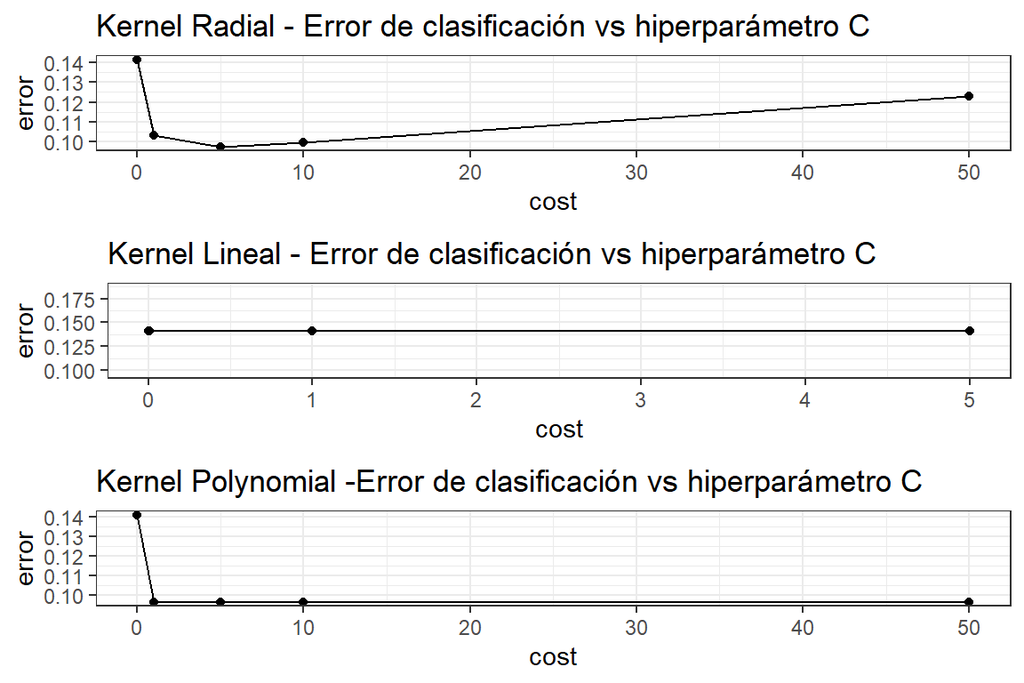

### Evaluación de los modelos en Test

A continuación se procede a probar la capacidad predictiva de los diferentes modelos analizando la matriz de confusión y el área bajo la curva ROC.

```
## [1] "Regresión"
##
## predi_y   no  yes
##     no  1286  197
##     yes    0   15
```

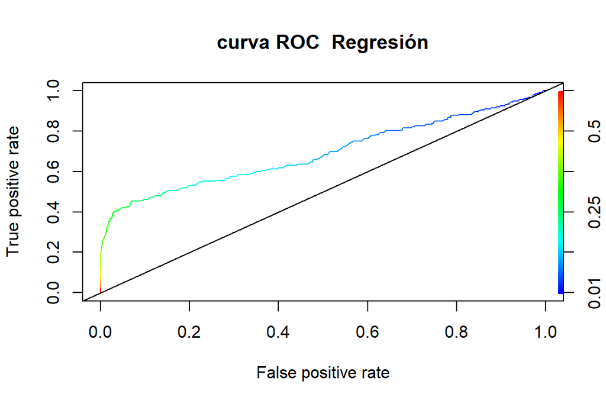

```
## [1] "Naive Bayes"
##
## pred    no  yes
##   no  1245  139
##   yes   41   73
```

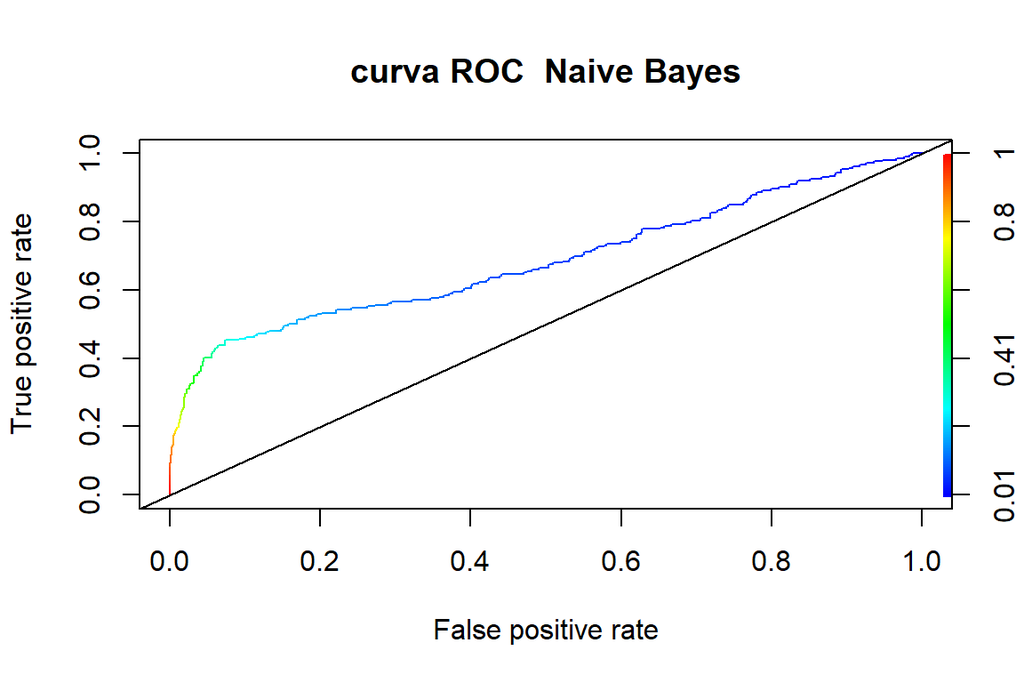

```
## [1] "KNN"
##
## pred    no  yes
##   no  1276  150
##   yes   10   62
```

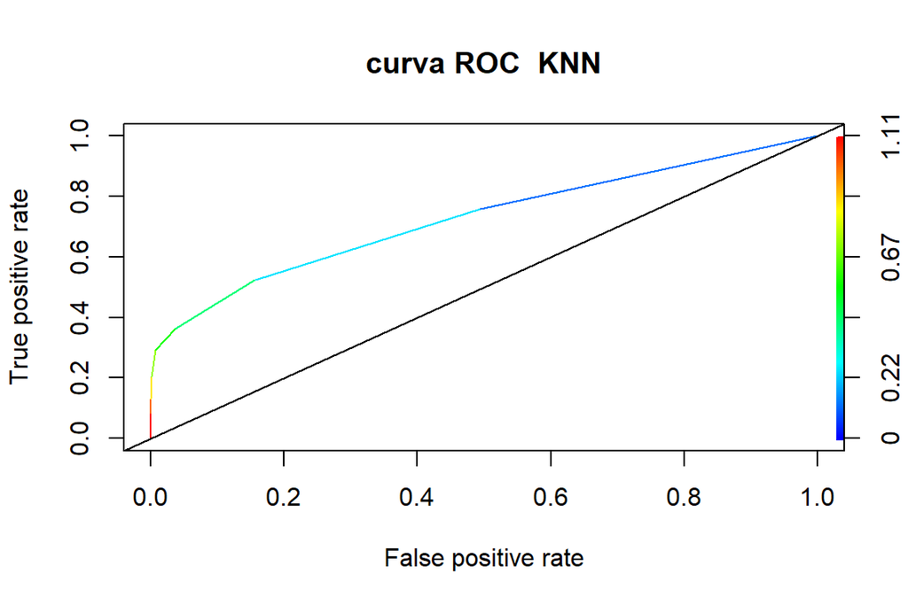

```
## [1] "Radial"
##
## pred    no  yes
##   no  1277  131
##   yes    9   81
```

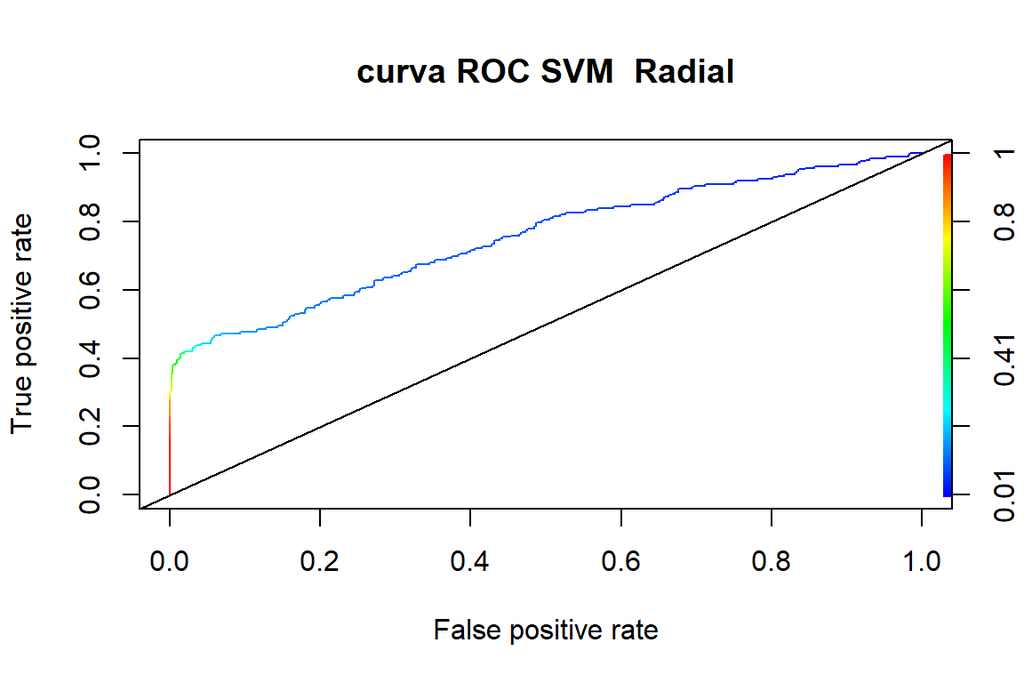

```
## [1] "Linear"
##
## pred    no  yes
##   no  1286  212
##   yes    0    0
```

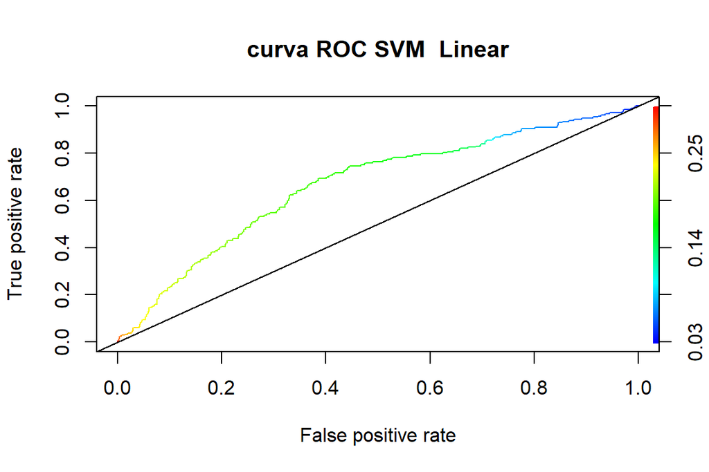

```
## [1] "Polinomial"
##
## pred    no  yes
##   no  1282  129
##   yes    4   83
```

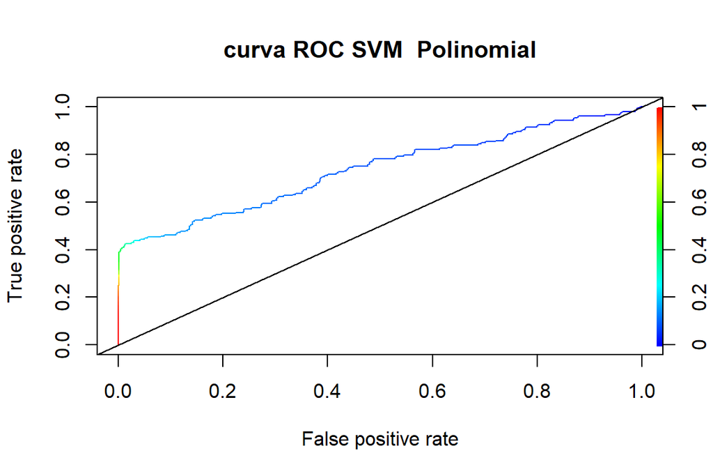

En la tabla de predicción de cada modelo podemos observar variaciones en la combinación de:

- **Verdaderos Negativos**: El modelo predice correctamente que el cliente NO cancela.
- **Falsos Negativos**: El modelo predice que el cliente NO cancela cuando en realidad SI cancela.
- **Falsos Positivos**: El modelo predice que el cliente SI cancela cuando en realidad NO cancela.
- **Verdaderos Positivos**: El modelo predice correctamente que el cliente SI cancela.

A los que hay que prestarle especial antención son a:

- **Falsos Negativos**: porque es un error costoso, son clientes que se podrían retener.
- **Verdaderos Positivos**: porque es el objetivo principal del modelo, que pueda predecir clientes que realmente van a cancelar.

Por otro lado, analizando el gráfico ROC, observamos que todos tienen una pendiente inicial ascendente parecida y tiende a la curva ideal (se generan menos falsos positivos), hasta el 0.4, excepto el SVM Lineal que parece ser el menos indicado para este conjunto de datos.

Comparación de Métricas entre Modelos

| Model | Accuracy | Sensitivity | Specificity | Precision | Area_ROC |
| --- | --- | --- | --- | --- | --- |
| Regresión | 0.8684913 | 0.0707547 | 1.0000000 | 1.0000000 | 0.6908397 |
| Naive Bayes | 0.8798398 | 0.3443396 | 0.9681182 | 0.6403509 | 0.6857009 |
| KNN | 0.8931909 | 0.2924528 | 0.9922240 | 0.8611111 | 0.7259731 |
| Radial | 0.9065421 | 0.3820755 | 0.9930016 | 0.9000000 | 0.7533598 |
| Linear | 0.8584780 | 0.0000000 | 1.0000000 | NaN | 0.6656262 |
| Polinomial | 0.9112150 | 0.3915094 | 0.9968896 | 0.9540230 | 0.7352365 |

Con estos resultados se debe tener en cuenta que:

- Se prioriza la SENSIBILIDAD cuando el costo del Falso Negativo es alto, pues se enfoca en minimizar los Falsos Negativos. En este caso, al predecir que un cliente NO cancelará y sí lo hace, perderíamoss un cliente sin intentar retenerlo.
- Se prioriza la ESPECIFICIDAD cuando el costo del Falso Positivo es alto, pues se enfoca en minimizar los Falsos Positivos. En este caso, al predecir que un cliente cancelará y no lo hace, se gastan recursos en un cliente que no estaba en riesgo de irse.

Cabe destacar que estos modelos, al priorizar los Falsos Negativos (caso de que un cliente no cancele cuando si lo hace), puede producir que no se le haga una promoción a un potencial cliente que va a cancelar.